# Reproducible Research-Project 1

# R preparations

In this document code will be represented to show how the results have been achieved. Set the default of echo to be true throughout the document:

# Load in the necessary packages

```r
library(knitr)
opts_chunk$set(echo = TRUE)
library(dplyr)
library(lubridate)
```

```r
library(ggplot2)
```

# Loading and preprocessing the data

The data is loaded using the read.csv()

# Reading in the data

```r
dataSet <- read.csv("activity.csv", header = TRUE, sep = ',')
```

# What is mean total number of steps taken per day?

1. Calculate the total number of steps per day:

```r
by_day<-aggregate(steps~date,dataSet,sum)
by_day$date<-as.Date(by_day$date,format="%Y-%m-%d")
```

2. Use ggplot for making the histogram:

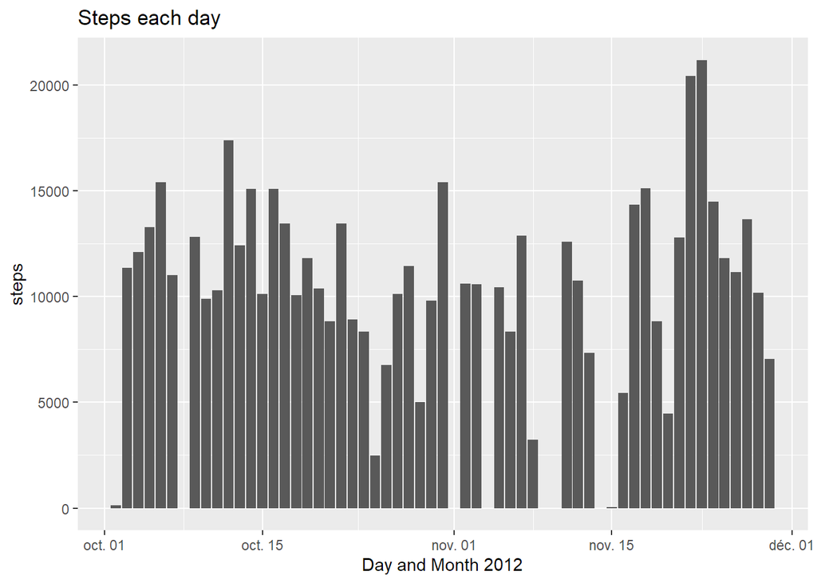

```r
ggplot(by_day, aes(x=date, y=steps)) + geom_bar(stat="identity") +
  #scale_x_datetime(breaks="1 week", labels=date_format("%d-%m")) +
  ylab("steps") + xlab("Day and Month 2012") +ggtitle("Steps each day")
```

3. Calculate the mean and median of the total number of steps taken per day:

```r
by_dayMean<-mean(by_day$steps,na.rm=TRUE)
by_dayMedian<-median(by_day$steps,na.rm=TRUE)
by_dayMean
```

```
## [1] 10766.19
```

```r
by_dayMedian
```

```
## [1] 10765
```

# What is the average daily activity pattern?

```r
by_interval<-aggregate(steps~interval,dataSet,mean)
head(by_interval)
```

```
##   interval     steps
## 1        0 1.7169811
## 2        5 0.3396226
## 3       10 0.1320755
## 4       15 0.1509434
## 5       20 0.0754717
## 6       25 2.0943396
```

Use ggplot for making the time series of the 5-minute interval and average steps taken:

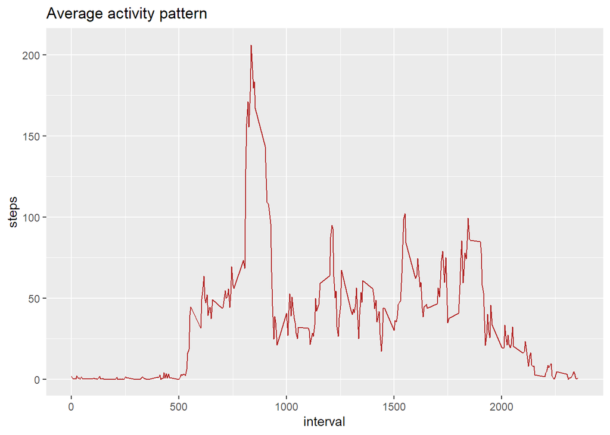

```r
ggplot(by_interval, aes(x=interval, y=steps)) +
  geom_line(color = "firebrick") +ggtitle("Average activity pattern")
```

```r
by_interval[max(by_interval$steps),]
```

```
##     interval    steps
## 206     1705 56.30189
```

# Imputing missing values

Note that there are a number of days/intervals where there are missing values (coded as NA). The presence of missing days may introduce bias into some calculations or summaries of the data.

1. Calculate and report the total number of missing values in the dataset (i.e. the total number of rows with NA):

```r
sum(is.na(dataSet$steps))
```

```
## [1] 2304
```

2.Devise a strategy for filling in all of the missing values in the dataset with the average of the steps in the others days.

```r
data_full <- dataSet
j<-0
for (i in 1:nrow(data_full)){
  j<-j+1
  if (is.na(data_full[i,1])){
    data_full[i,1]<-by_interval[j,2]
  }

  if(data_full[i,2]!=data_full[i+1,2] & i+1<nrow(data_full))
    j<-0
}
```

```r
head(data_full)
```

```
##       steps       date interval
## 1 1.7169811 2012-10-01        0
## 2 0.3396226 2012-10-01        5
## 3 0.1320755 2012-10-01       10
## 4 0.1509434 2012-10-01       15
## 5 0.0754717 2012-10-01       20
## 6 2.0943396 2012-10-01       25
```

```r
by_day_Integrate<-aggregate(steps~date,data_full,sum)
by_day_Integrate$date<-as.Date(by_day_Integrate$date,format="%Y-%m-%d")
```

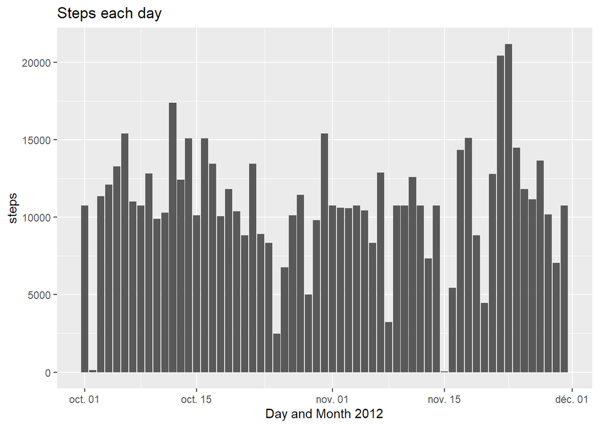

```r
ggplot(by_day_Integrate, aes(x=date, y=steps)) + geom_bar(stat="identity") +
  #scale_x_date(breaks="1 week", labels=date_format("%d-%m")) +
  ylab("steps") + xlab("Day and Month 2012") +ggtitle("Steps each day")
```

# Calculate the mean and median steps with the filled in values:

```r
by_day_Integrate_Mean<-mean(by_day_Integrate$steps,na.rm=TRUE)
by_day_Integrate_Median<-median(by_day_Integrate$steps,na.rm=TRUE)
by_day_Integrate_Mean
```

```
## [1] 10766.19
```

```r
by_day_Integrate_Median
```

```
## [1] 10766.19
```

# Are there differences in activity patterns between weekdays and weekends?

For this part the weekdays() will come handy. Use the dataset with the filled-in missing values for this part.

1. Create a new factor variable in the dataset with two levels - “weekday” and “weekend” indicating whether a given date is a weekday or weekend day.

```r
data_full$date<-as.Date(data_full$date,format="%Y-%m-%d")

for (i in 1:nrow(data_full)){
  if (weekdays(data_full[i,2])=="samedi" | weekdays(data_full[i,2])=="dimanche"){
    data_full[i,4]<-"Weekend"
  }
  else
    data_full[i,4]<-"Weekday"
}
```

2. Make a panel plot containing a time series plot (i.e. type = “l”) of the 5-minute interval (x-axis) and the average number of steps taken, averaged across all weekday days or weekend days (y-axis).

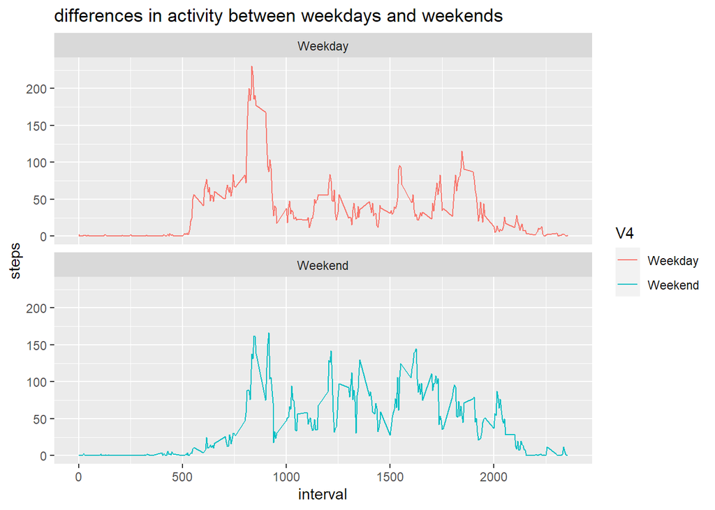

```r
interval_full <- data_full %>%
  group_by(interval, V4) %>%
  summarise(steps = mean(steps))

ggplot(interval_full, aes(x=interval, y=steps, color = V4)) +
  geom_line() +ggtitle(("differences in activity between weekdays and weekends"))+
  facet_wrap(~V4, ncol = 1, nrow=2)
```